# ~Crazy Super Awesome HW2~

Izzy Gaw

2020-01-26

Hello! This page is Izzy’s Homework 2 for R Bootcamp.

On this page, you will find my code and visual representations of the Iris Dataset, a further investigation from our Homework 1.

```r
read.csv("iris.csv")
```

```
##     Sepal.Length Sepal.Width Petal.Length Petal.Width    Species
## 1            5.1         3.5          1.4         0.2     setosa
## 2            4.9         3.0          1.4         0.2     setosa
## 3            4.7         3.2          1.3         0.2     setosa
## 4            4.6         3.1          1.5         0.2     setosa
## 5            5.0         3.6          1.4         0.2     setosa
## 6            5.4         3.9          1.7         0.4     setosa
## 7            4.6         3.4          1.4         0.3     setosa
## 8            5.0         3.4          1.5         0.2     setosa
## 9            4.4         2.9          1.4         0.2     setosa
## 10           4.9         3.1          1.5         0.1     setosa
## 11           5.4         3.7          1.5         0.2     setosa
## 12           4.8         3.4          1.6         0.2     setosa
## 13           4.8         3.0          1.4         0.1     setosa
## 14           4.3         3.0          1.1         0.1     setosa
```

[output cut: 136 more lines]

```r
iris
```

```
##     sepalL sepalW petalL petalW    species
## 1      5.1    3.5    1.4    0.2     setosa
## 2      4.9    3.0    1.4    0.2     setosa
## 3      4.7    3.2    1.3    0.2     setosa
## 4      4.6    3.1    1.5    0.2     setosa
## 5      5.0    3.6    1.4    0.2     setosa
## 6      5.4    3.9    1.7    0.4     setosa
## 7      4.6    3.4    1.4    0.3     setosa
## 8      5.0    3.4    1.5    0.2     setosa
## 9      4.4    2.9    1.4    0.2     setosa
## 10     4.9    3.1    1.5    0.1     setosa
## 11     5.4    3.7    1.5    0.2     setosa
## 12     4.8    3.4    1.6    0.2     setosa
## 13     4.8    3.0    1.4    0.1     setosa
## 14     4.3    3.0    1.1    0.1     setosa
```

[output cut: 136 more lines]

```r
dim(iris)
```

```
## [1] 150   5
```

```r
names (iris)
```

```
## [1] "sepalL"  "sepalW"  "petalL"  "petalW"  "species"
```

```r
names(iris) <- c("sepalL", "sepalW",  "petalL", "petalW", "species")
names(iris)
```

```
## [1] "sepalL"  "sepalW"  "petalL"  "petalW"  "species"
```

```r
x <- iris$sepalL
x
```

```
##   [1] 5.1 4.9 4.7 4.6 5.0 5.4 4.6 5.0 4.4 4.9 5.4 4.8 4.8 4.3 5.8 5.7 5.4 5.1
##  [19] 5.7 5.1 5.4 5.1 4.6 5.1 4.8 5.0 5.0 5.2 5.2 4.7 4.8 5.4 5.2 5.5 4.9 5.0
##  [37] 5.5 4.9 4.4 5.1 5.0 4.5 4.4 5.0 5.1 4.8 5.1 4.6 5.3 5.0 7.0 6.4 6.9 5.5
##  [55] 6.5 5.7 6.3 4.9 6.6 5.2 5.0 5.9 6.0 6.1 5.6 6.7 5.6 5.8 6.2 5.6 5.9 6.1
##  [73] 6.3 6.1 6.4 6.6 6.8 6.7 6.0 5.7 5.5 5.5 5.8 6.0 5.4 6.0 6.7 6.3 5.6 5.5
##  [91] 5.5 6.1 5.8 5.0 5.6 5.7 5.7 6.2 5.1 5.7 6.3 5.8 7.1 6.3 6.5 7.6 4.9 7.3
## [109] 6.7 7.2 6.5 6.4 6.8 5.7 5.8 6.4 6.5 7.7 7.7 6.0 6.9 5.6 7.7 6.3 6.7 7.2
## [127] 6.2 6.1 6.4 7.2 7.4 7.9 6.4 6.3 6.1 7.7 6.3 6.4 6.0 6.9 6.7 6.9 5.8 6.8
## [145] 6.7 6.7 6.3 6.5 6.2 5.9
```

```r
y <- iris$petalL
y
```

```
##   [1] 1.4 1.4 1.3 1.5 1.4 1.7 1.4 1.5 1.4 1.5 1.5 1.6 1.4 1.1 1.2 1.5 1.3 1.4
##  [19] 1.7 1.5 1.7 1.5 1.0 1.7 1.9 1.6 1.6 1.5 1.4 1.6 1.6 1.5 1.5 1.4 1.5 1.2
##  [37] 1.3 1.4 1.3 1.5 1.3 1.3 1.3 1.6 1.9 1.4 1.6 1.4 1.5 1.4 4.7 4.5 4.9 4.0
##  [55] 4.6 4.5 4.7 3.3 4.6 3.9 3.5 4.2 4.0 4.7 3.6 4.4 4.5 4.1 4.5 3.9 4.8 4.0
##  [73] 4.9 4.7 4.3 4.4 4.8 5.0 4.5 3.5 3.8 3.7 3.9 5.1 4.5 4.5 4.7 4.4 4.1 4.0
##  [91] 4.4 4.6 4.0 3.3 4.2 4.2 4.2 4.3 3.0 4.1 6.0 5.1 5.9 5.6 5.8 6.6 4.5 6.3
## [109] 5.8 6.1 5.1 5.3 5.5 5.0 5.1 5.3 5.5 6.7 6.9 5.0 5.7 4.9 6.7 4.9 5.7 6.0
## [127] 4.8 4.9 5.6 5.8 6.1 6.4 5.6 5.1 5.6 6.1 5.6 5.5 4.8 5.4 5.6 5.1 5.1 5.9
## [145] 5.7 5.2 5.0 5.2 5.4 5.1
```

```r
fit <- lm(y ~x)
fit #check
```

```
##
## Call:
## lm(formula = y ~ x)
##
## Coefficients:
## (Intercept)            x
##      -7.101        1.858
```

```r
b <- coef( fit )
b
```

```
## (Intercept)           x
##   -7.101443    1.858433
```

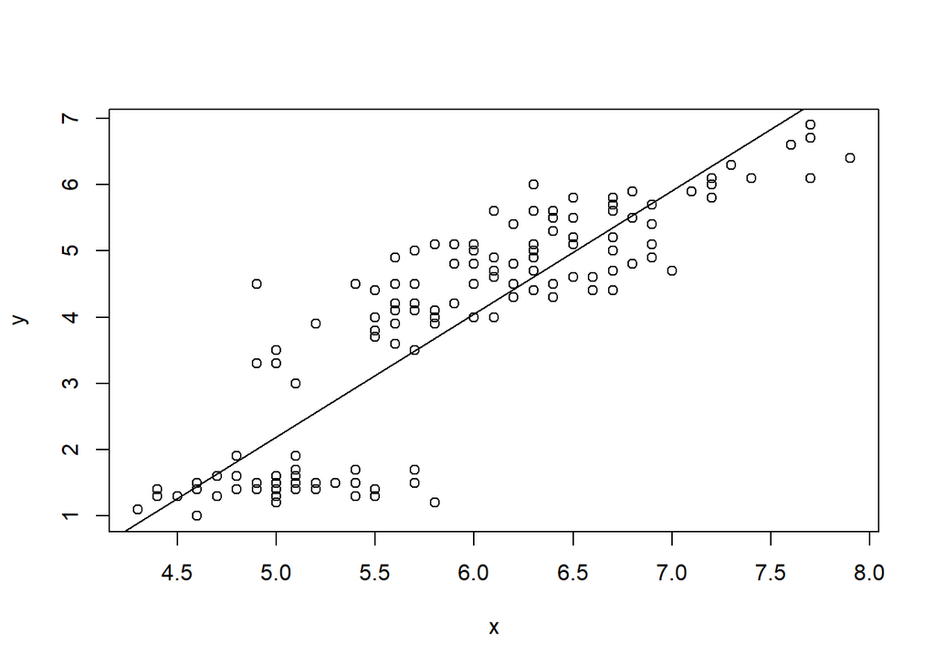

```r
int <- b[1]
slope <- b[2]
plot(x, y)
abline(fit)
```

INITIAL SET-UP. Scatterplot of Sepal Length and Petal Length of three different species sampled (Iris setosa, Iris virginica, and Iris versicolor) and a regression line.

```r
read.csv("iris.csv")
```

```
##     Sepal.Length Sepal.Width Petal.Length Petal.Width    Species
## 1            5.1         3.5          1.4         0.2     setosa
## 2            4.9         3.0          1.4         0.2     setosa
## 3            4.7         3.2          1.3         0.2     setosa
## 4            4.6         3.1          1.5         0.2     setosa
## 5            5.0         3.6          1.4         0.2     setosa
## 6            5.4         3.9          1.7         0.4     setosa
## 7            4.6         3.4          1.4         0.3     setosa
## 8            5.0         3.4          1.5         0.2     setosa
## 9            4.4         2.9          1.4         0.2     setosa
## 10           4.9         3.1          1.5         0.1     setosa
## 11           5.4         3.7          1.5         0.2     setosa
## 12           4.8         3.4          1.6         0.2     setosa
## 13           4.8         3.0          1.4         0.1     setosa
## 14           4.3         3.0          1.1         0.1     setosa
```

[output cut: 136 more lines]

```r
iris
```

```
##     sepalL sepalW petalL petalW    species
## 1      5.1    3.5    1.4    0.2     setosa
## 2      4.9    3.0    1.4    0.2     setosa
## 3      4.7    3.2    1.3    0.2     setosa
## 4      4.6    3.1    1.5    0.2     setosa
## 5      5.0    3.6    1.4    0.2     setosa
## 6      5.4    3.9    1.7    0.4     setosa
## 7      4.6    3.4    1.4    0.3     setosa
## 8      5.0    3.4    1.5    0.2     setosa
## 9      4.4    2.9    1.4    0.2     setosa
## 10     4.9    3.1    1.5    0.1     setosa
## 11     5.4    3.7    1.5    0.2     setosa
## 12     4.8    3.4    1.6    0.2     setosa
## 13     4.8    3.0    1.4    0.1     setosa
## 14     4.3    3.0    1.1    0.1     setosa
```

[output cut: 136 more lines]

```r
dim(iris)
```

```
## [1] 150   5
```

```r
names (iris)
```

```
## [1] "sepalL"  "sepalW"  "petalL"  "petalW"  "species"
```

```r
names(iris) <- c("sepalL", "sepalW",  "petalL", "petalW", "species")
names(iris)
```

```
## [1] "sepalL"  "sepalW"  "petalL"  "petalW"  "species"
```

```r
x <- iris$sepalL
y <- iris$petalL
fit <- lm(y ~x)
fit #check
```

```
##
## Call:
## lm(formula = y ~ x)
##
## Coefficients:
## (Intercept)            x
##      -7.101        1.858
```

```r
b <- coef( fit )
int <- b[1]
slope <- b[2]
plot(x, y)
abline(fit)
yhat <- slope*x + int
points( x, yhat, pch=3)
i=150
segments( x[i], y[i], x[i], yhat[i], col="red" )
segments( x, y, x, yhat, col="red", lty=2 )
error <- yhat - y
error
```

```
##   [1]  0.976564819  0.604878224  0.333191628 -0.052651670  0.790721522
##   [6]  1.234094713  0.047348330  0.690721522 -0.324338265  0.504878224
##  [11]  1.434094713  0.219034926  0.419034926 -0.210181563  2.477467904
##  [16]  1.991624606  1.634094713  0.976564819  1.791624606  0.876564819
##  [21]  1.234094713  0.876564819  0.447348330  0.676564819 -0.080965074
##  [26]  0.590721522  0.590721522  1.062408117  1.162408117  0.033191628
##  [31]  0.219034926  1.434094713  1.062408117  1.719938011  0.504878224
##  [36]  0.990721522  1.819938011  0.604878224 -0.224338265  0.876564819
##  [41]  0.890721522 -0.038494967 -0.224338265  0.590721522  0.476564819
##  [46]  0.419034926  0.776564819  0.047348330  1.248251415  0.790721522
##  [51]  1.207587478  0.292527691  0.821744180 -0.880061989  0.378370989
##  [56] -1.008375394 -0.093315607 -1.295121776  0.564214287 -1.337591883
##  [61] -1.309278478 -0.336688798  0.049154500 -0.465002202 -0.294218691
##  [66]  0.950057585 -1.194218691 -0.422532096 -0.079158904 -0.594218691
##  [71] -0.936688798  0.234997798 -0.293315607 -0.465002202  0.492527691
##  [76]  0.764214287  0.735900883  0.350057585 -0.450845500 -0.008375394
##  [81] -0.680061989 -0.580061989 -0.222532096 -1.050845500 -1.565905287
##  [86] -0.450845500  0.650057585  0.206684393 -0.794218691 -0.880061989
##  [91] -1.280061989 -0.365002202 -0.322532096 -1.109278478 -0.894218691
##  [96] -0.708375394 -0.708375394  0.120841096 -0.623435181 -0.608375394
## [101] -1.393315607 -1.422532096  0.193430776 -0.993315607 -0.821629011
## [106]  0.422647265 -2.495121776  0.165117372 -0.449942415  0.179274074
## [111] -0.121629011 -0.507472309  0.035900883 -1.508375394 -1.422532096
## [116] -0.507472309 -0.521629011  0.508490563  0.308490563 -0.950845500
## [121]  0.021744180 -1.594218691  0.508490563 -0.293315607 -0.349942415
## [126]  0.279274074 -0.379158904 -0.665002202 -0.807472309  0.479274074
## [131]  0.550960669  1.180177159 -0.807472309 -0.493315607 -1.365002202
## [136]  1.108490563 -0.993315607 -0.707472309 -0.750845500  0.321744180
## [141] -0.249942415  0.621744180 -1.422532096 -0.364099117 -0.349942415
## [146]  0.150057585 -0.393315607 -0.221629011 -0.979158904 -1.236688798
```

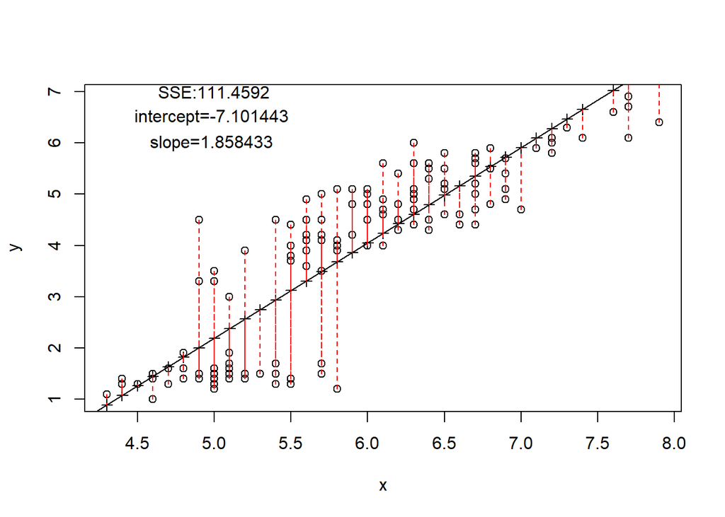

```r
sse <- sum((error)^2)
text( 5, 7, paste("SSE:111.4592"))
text(5, 6.5, paste("intercept=-7.101443 "))
text(5, 6, paste("slope=1.858433 "))
```

ADDING REGRESSION + ERROR. Scatterplot of Sepal Length and Petal Length of the same three species as above, however, here I also added the sum of squared errors lines from the slope to demonstrate that this is in fact the best fitted slope. I have made the lines red so they stand out from the plotted points and the regression line.

```r
iris
```

```
##     sepalL sepalW petalL petalW    species
## 1      5.1    3.5    1.4    0.2     setosa
## 2      4.9    3.0    1.4    0.2     setosa
## 3      4.7    3.2    1.3    0.2     setosa
## 4      4.6    3.1    1.5    0.2     setosa
## 5      5.0    3.6    1.4    0.2     setosa
## 6      5.4    3.9    1.7    0.4     setosa
## 7      4.6    3.4    1.4    0.3     setosa
## 8      5.0    3.4    1.5    0.2     setosa
## 9      4.4    2.9    1.4    0.2     setosa
## 10     4.9    3.1    1.5    0.1     setosa
## 11     5.4    3.7    1.5    0.2     setosa
## 12     4.8    3.4    1.6    0.2     setosa
## 13     4.8    3.0    1.4    0.1     setosa
## 14     4.3    3.0    1.1    0.1     setosa
```

[output cut: 136 more lines]

```r
dim(iris)
```

```
## [1] 150   5
```

```r
names (iris)
```

```
## [1] "sepalL"  "sepalW"  "petalL"  "petalW"  "species"
```

```r
names(iris) <- c("sepalL", "sepalW",  "petalL", "petalW", "species")
names(iris)
```

```
## [1] "sepalL"  "sepalW"  "petalL"  "petalW"  "species"
```

```r
x <- iris$sepalL
y <- iris$petalL
fit <- lm(y ~x)
fit #check
```

```
##
## Call:
## lm(formula = y ~ x)
##
## Coefficients:
## (Intercept)            x
##      -7.101        1.858
```

```r
b <- coef( fit )
int <- b[1]
slope <- b[2]
plot(x, y)
abline(fit)
yhat <- slope*x + int
points( x, yhat, pch=3)
i=150
segments( x[i], y[i], x[i], yhat[i], col="red" )
segments( x, y, x, yhat, col="red", lty=2 )
error <- yhat - y
error
```

```
##   [1]  0.976564819  0.604878224  0.333191628 -0.052651670  0.790721522
##   [6]  1.234094713  0.047348330  0.690721522 -0.324338265  0.504878224
##  [11]  1.434094713  0.219034926  0.419034926 -0.210181563  2.477467904
##  [16]  1.991624606  1.634094713  0.976564819  1.791624606  0.876564819
##  [21]  1.234094713  0.876564819  0.447348330  0.676564819 -0.080965074
##  [26]  0.590721522  0.590721522  1.062408117  1.162408117  0.033191628
##  [31]  0.219034926  1.434094713  1.062408117  1.719938011  0.504878224
##  [36]  0.990721522  1.819938011  0.604878224 -0.224338265  0.876564819
##  [41]  0.890721522 -0.038494967 -0.224338265  0.590721522  0.476564819
##  [46]  0.419034926  0.776564819  0.047348330  1.248251415  0.790721522
##  [51]  1.207587478  0.292527691  0.821744180 -0.880061989  0.378370989
##  [56] -1.008375394 -0.093315607 -1.295121776  0.564214287 -1.337591883
##  [61] -1.309278478 -0.336688798  0.049154500 -0.465002202 -0.294218691
##  [66]  0.950057585 -1.194218691 -0.422532096 -0.079158904 -0.594218691
##  [71] -0.936688798  0.234997798 -0.293315607 -0.465002202  0.492527691
##  [76]  0.764214287  0.735900883  0.350057585 -0.450845500 -0.008375394
##  [81] -0.680061989 -0.580061989 -0.222532096 -1.050845500 -1.565905287
##  [86] -0.450845500  0.650057585  0.206684393 -0.794218691 -0.880061989
##  [91] -1.280061989 -0.365002202 -0.322532096 -1.109278478 -0.894218691
##  [96] -0.708375394 -0.708375394  0.120841096 -0.623435181 -0.608375394
## [101] -1.393315607 -1.422532096  0.193430776 -0.993315607 -0.821629011
## [106]  0.422647265 -2.495121776  0.165117372 -0.449942415  0.179274074
## [111] -0.121629011 -0.507472309  0.035900883 -1.508375394 -1.422532096
## [116] -0.507472309 -0.521629011  0.508490563  0.308490563 -0.950845500
## [121]  0.021744180 -1.594218691  0.508490563 -0.293315607 -0.349942415
## [126]  0.279274074 -0.379158904 -0.665002202 -0.807472309  0.479274074
## [131]  0.550960669  1.180177159 -0.807472309 -0.493315607 -1.365002202
## [136]  1.108490563 -0.993315607 -0.707472309 -0.750845500  0.321744180
## [141] -0.249942415  0.621744180 -1.422532096 -0.364099117 -0.349942415
## [146]  0.150057585 -0.393315607 -0.221629011 -0.979158904 -1.236688798
```

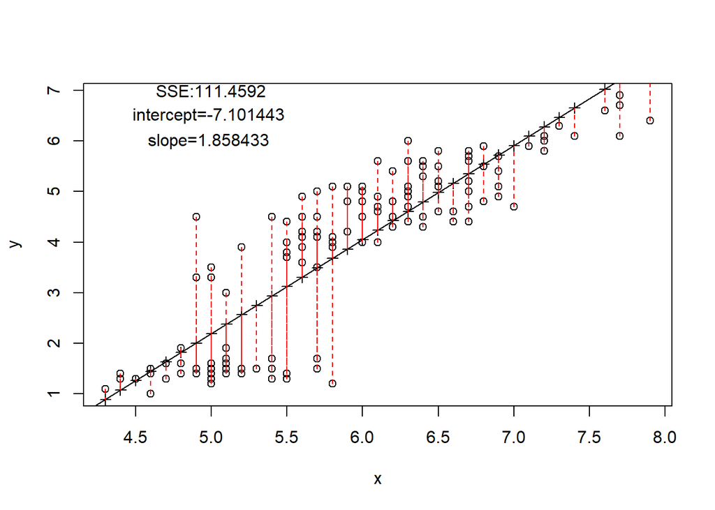

```r
sse <- sum((error)^2)
text( 5, 7, paste("SSE:111.4592"))
text(5, 6.5, paste("intercept=-7.101443 "))
text(5, 6, paste("slope=1.858433 "))
```

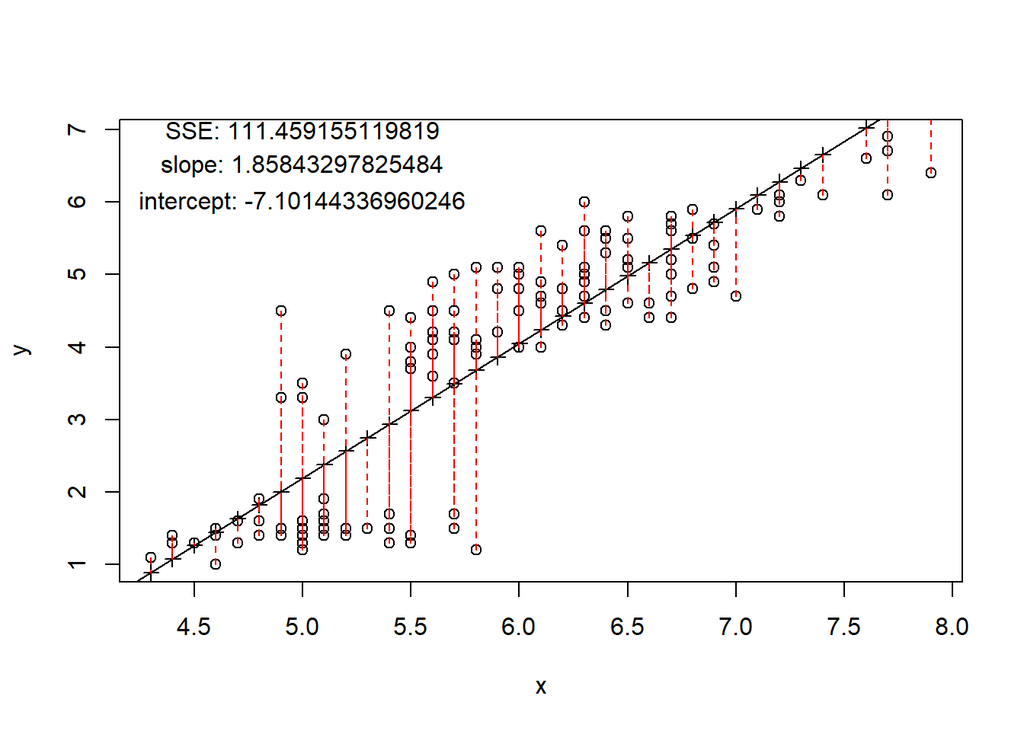

```
## function(x=iris$sepalL, y=iris$petalL, newint=int, newslope=slope) {
##  yhat <- newslope*x + newint
##  error <- yhat - y
##  sse <- sum(error^2)
##  plot(x, y)
##  abline(newint, newslope)
##  points(x, yhat, pch=3)
##  segments(x, y, x, yhat,col="red", lty=2)
##  text(5,7, paste("SSE:", sse))
##  text(5,6.5, paste("slope:", slope))
##  text(5,6, paste("intercept:", int))
##  print(customplot)
## }
## <bytecode: 0x0000000004c3a0b8>
```

```r
customplot <- function(x=iris$sepalL, y=iris$petalL, newint=int, newslope=slope) {
    yhat <- newslope*x + newint
    error <- yhat - y
    sse <- sum(error^2)
    plot(x, y)
    abline(newint, newslope)
    points(x, yhat, pch=3)
    segments(x, y, x, yhat,col="red", lty=2)
    text(5,7, paste("SSE:", sse))
    text(5,6.5, paste("slope:", slope))
    text(5,6, paste("intercept:", int))
    print(customplot)
}

customplot()
```

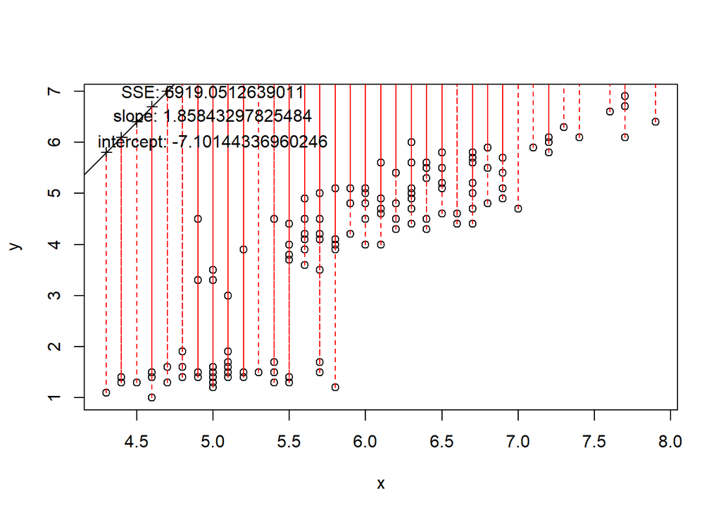

```
## function(x=iris$sepalL, y=iris$petalL, newint=int, newslope=slope) {
##  yhat <- newslope*x + newint
##  error <- yhat - y
##  sse <- sum(error^2)
##  plot(x, y)
##  abline(newint, newslope)
##  points(x, yhat, pch=3)
##  segments(x, y, x, yhat,col="red", lty=2)
##  text(5,7, paste("SSE:", sse))
##  text(5,6.5, paste("slope:", slope))
##  text(5,6, paste("intercept:", int))
##  print(customplot)
## }
## <bytecode: 0x0000000004c3a0b8>
```

```r
customplot(newslope=3) #slope is not in the right place, moved up
```

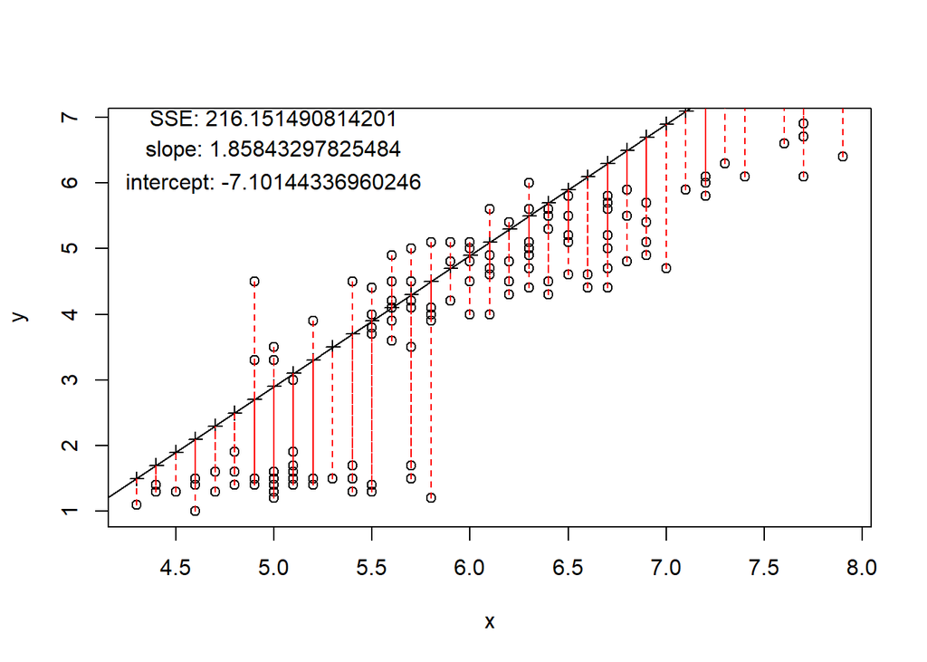

```
## function(x=iris$sepalL, y=iris$petalL, newint=int, newslope=slope) {
##  yhat <- newslope*x + newint
##  error <- yhat - y
##  sse <- sum(error^2)
##  plot(x, y)
##  abline(newint, newslope)
##  points(x, yhat, pch=3)
##  segments(x, y, x, yhat,col="red", lty=2)
##  text(5,7, paste("SSE:", sse))
##  text(5,6.5, paste("slope:", slope))
##  text(5,6, paste("intercept:", int))
##  print(customplot)
## }
## <bytecode: 0x0000000004c3a0b8>
```

```r
customplot(newslope=2) #slope is not in the right place, moved up
```

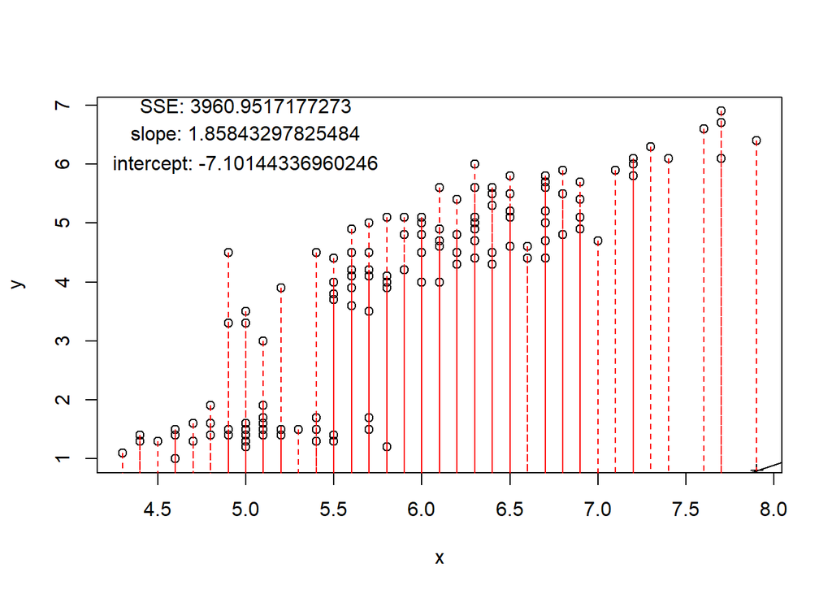

```
## function(x=iris$sepalL, y=iris$petalL, newint=int, newslope=slope) {
##  yhat <- newslope*x + newint
##  error <- yhat - y
##  sse <- sum(error^2)
##  plot(x, y)
##  abline(newint, newslope)
##  points(x, yhat, pch=3)
##  segments(x, y, x, yhat,col="red", lty=2)
##  text(5,7, paste("SSE:", sse))
##  text(5,6.5, paste("slope:", slope))
##  text(5,6, paste("intercept:", int))
##  print(customplot)
## }
## <bytecode: 0x0000000004c3a0b8>
```

```r
customplot(newslope=1) # slope is not in the right place, all the way down
```

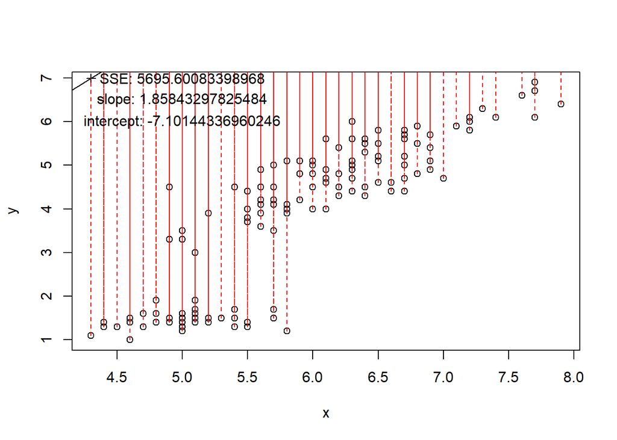

```
## function(x=iris$sepalL, y=iris$petalL, newint=int, newslope=slope) {
##  yhat <- newslope*x + newint
##  error <- yhat - y
##  sse <- sum(error^2)
##  plot(x, y)
##  abline(newint, newslope)
##  points(x, yhat, pch=3)
##  segments(x, y, x, yhat,col="red", lty=2)
##  text(5,7, paste("SSE:", sse))
##  text(5,6.5, paste("slope:", slope))
##  text(5,6, paste("intercept:", int))
##  print(customplot)
## }
## <bytecode: 0x0000000004c3a0b8>
```

```r
customplot(newint=-1) #slope barely even on the graph!All the way on the top
```

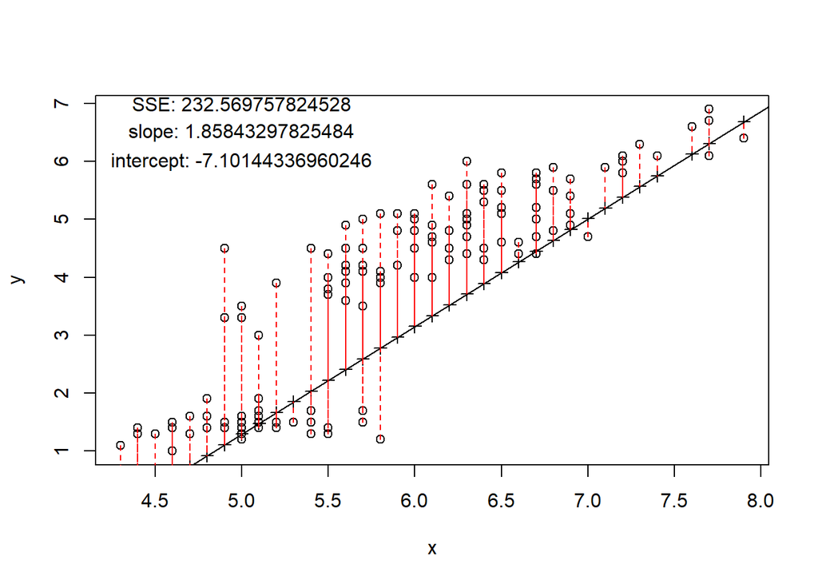

```
## function(x=iris$sepalL, y=iris$petalL, newint=int, newslope=slope) {
##  yhat <- newslope*x + newint
##  error <- yhat - y
##  sse <- sum(error^2)
##  plot(x, y)
##  abline(newint, newslope)
##  points(x, yhat, pch=3)
##  segments(x, y, x, yhat,col="red", lty=2)
##  text(5,7, paste("SSE:", sse))
##  text(5,6.5, paste("slope:", slope))
##  text(5,6, paste("intercept:", int))
##  print(customplot)
## }
## <bytecode: 0x0000000004c3a0b8>
```

```r
customplot(newint=-8) #below the correct place!
```

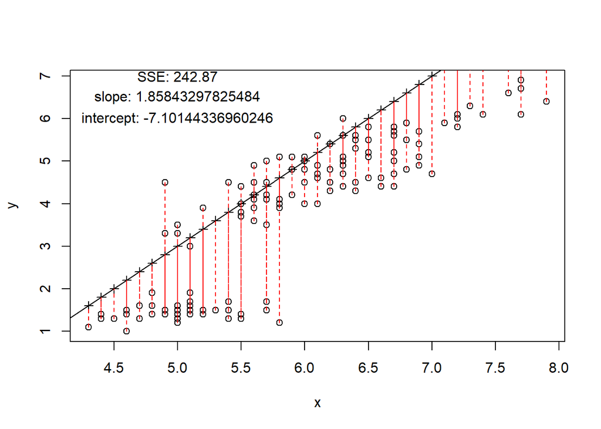

```
## function(x=iris$sepalL, y=iris$petalL, newint=int, newslope=slope) {
##  yhat <- newslope*x + newint
##  error <- yhat - y
##  sse <- sum(error^2)
##  plot(x, y)
##  abline(newint, newslope)
##  points(x, yhat, pch=3)
##  segments(x, y, x, yhat,col="red", lty=2)
##  text(5,7, paste("SSE:", sse))
##  text(5,6.5, paste("slope:", slope))
##  text(5,6, paste("intercept:", int))
##  print(customplot)
## }
## <bytecode: 0x0000000004c3a0b8>
```

```r
customplot(newslope=2, newint=-7) #slope above the correct place
```

WRAP IN CUSTOM CODE. Here I have made a custom plot that further demonstrates that the regression slope is truly the best fit. I tried 6 different times to find an error in my found slope, however, it does seem the regression found is the best fit.

```r
izzysfunction <- function( x ) {
  return ( (x*x/2+7-12)/1 )
}

izzysfunction(4)
```

```
## [1] 3
```

FUNCTIONS. Above is Izzy’s function. It is a crazy function just to practice making a function.

```r
absolutevalue <- function(y) {
  y= if (y<1)return (y*-1) else y
  print(y)
}

absolutevalue(-3)
```

```
## [1] 3
```

```r
absolutevalue(3)
```

```
## [1] 3
```

```r
absolutevalue2 <- function(y) {
y = if (y<1) y*-1 else y
print(y)
}

absolutevalue2(5)
```

```
## [1] 5
```

```r
absolutevalue(-5)
```

```
## [1] 5
```

MORE FUNCTIONS. Here I made two different absolute value functions. They both work!

```r
ChangeinPOPsize <- function(POP) {

#change=252642.5 #(dP/dt)...change in population size
r=0.2311 #intrinsic rate of increase (real number)
P=POP #=1000000  #population
P0=900000#initial population
K=1072764 #carrying capacity

change <- (r*P*((1-(P0-P)/K)))
print(change)
}

ChangeinPOPsize(100000)
```

```
## [1] 5876.014
```

EVEN MORE FUNCTIONS. Here I made a carrying capacity function. You input the population size in the function, and the output is the change in population over time. The user could also change the parameters inside the function, such as the K or r.